[figure not shown]

# Python Bootcamp

### August 19-20, 2017, Seattle, WA

# Exercise: Numpy, Scipy, Matplotlib

The following series of exercises are designed to give you more practice manipulating and plotting data using Numpy, Scipy, and Matplotlib

```python
import numpy as np
import matplotlib.pyplot as plt
import scipy.misc
import scipy.ndimage
from __future__ import print_function

%matplotlib notebook
```

# Scipy has a built in image called 'face' that we can use to do some image processing

The exercises below will walk you through various basic operations on this image

First, make a variabled called "face" that contains the image

```python
face = scipy.misc.face()
```

# What is the image?

Show the image using matplotlib

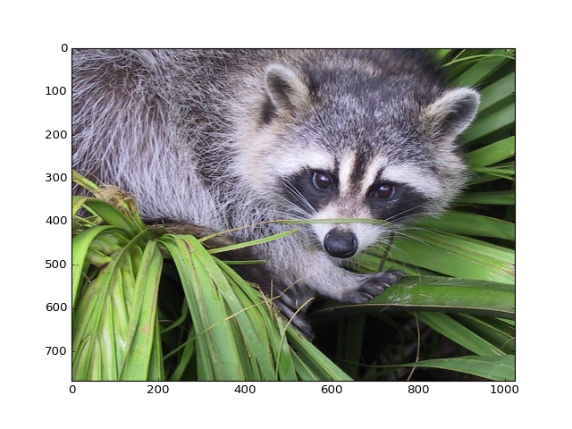

```python
# Answer
fig,ax=plt.subplots()
ax.imshow(face)
```

# What is the shape of the image?

```python
#answer (two ways of doing it)
print("the shape of the image is: ",face.shape)
print("the shape of the image is: ",np.shape(face))
```

```
the shape of the image is:  (768, 1024, 3)
the shape of the image is:  (768, 1024, 3)
```

Make note of the fact that the first two dimensions are ROWS x COLUMNS. When indexing into this array, you'll need to use this convention, as opposed to thinking of X and Y position (which would actually be column and row, respectively).

# What is the intensity range for the pixel values?

hint: use the 'flatten' method to make a 1-D array, then make a histogram

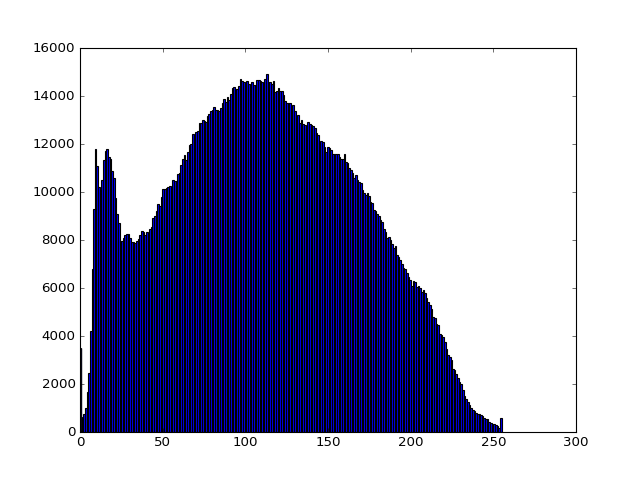

```
minimum value:  0
maximum value:  255
```

```python
face_flat = face.flatten()
fig,ax=plt.subplots()
ax.hist(face_flat,bins=256);
print('minimum value: ',np.min(face_flat))
print('maximum value: ',np.max(face_flat))
```

# The third image dimension refers to the number of color channels (R,G,B).

Try making an array of equal size to the image, but that contains only the color at a given pixel (for example, find a pixel on a leaf, then display an array that contains only that color)

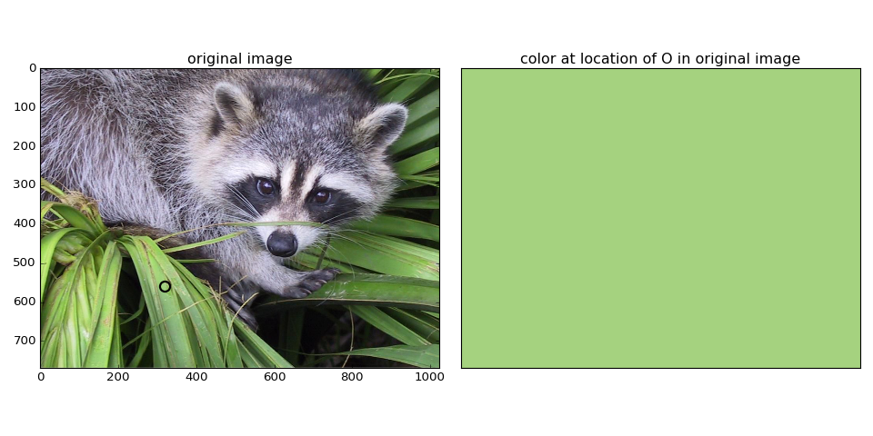

```python
Px = 320
Py = 560

fig,ax=plt.subplots(1,2,figsize=(12,6))
ax[0].imshow(face)
ax[0].plot(Px,Py,'o',markersize=10,markeredgewidth=2,color='none', markeredgecolor='k')

ax[0].set_xlim(0,1024)
ax[0].set_ylim(768,0)
ax[0].set_title('original image')

color_array = np.ones_like(face)
color_array[:,:,:] = face[Py,Px,:3]
ax[1].imshow(color_array)
ax[1].set_title('color at location of O in original image')
ax[1].set_xticks([])
ax[1].set_yticks([])

fig.tight_layout()
```